# R Example 9: Inverse propensity score weighting

We still use the lalonde data from the MatchIt package and use the propensity score model that we found out in R example 7.

```r
library("MatchIt")
data("lalonde")

model <- glm(treat ~ . , data = lalonde[, -9], family = "binomial")
eps <- predict(model, type = "response")

lalonde
```

|  | treat | age | educ | race | married | nodegree | re74 | re75 | re78 |
| --- | --- | --- | --- | --- | --- | --- | --- | --- | --- |
| NSW1 | 1 | 37 | 11 | black | 1 | 1 | 0.00000 | 0.00000 | 9930.04600 |
| NSW2 | 1 | 22 | 9 | hispan | 0 | 1 | 0.00000 | 0.00000 | 3595.89400 |
| NSW3 | 1 | 30 | 12 | black | 0 | 0 | 0.00000 | 0.00000 | 24909.45000 |
| NSW4 | 1 | 27 | 11 | black | 0 | 1 | 0.00000 | 0.00000 | 7506.14600 |
| NSW5 | 1 | 33 | 8 | black | 0 | 1 | 0.00000 | 0.00000 | 289.78990 |
| NSW6 | 1 | 22 | 9 | black | 0 | 1 | 0.00000 | 0.00000 | 4056.49400 |
| NSW7 | 1 | 23 | 12 | black | 0 | 0 | 0.00000 | 0.00000 | 0.00000 |
| NSW8 | 1 | 32 | 11 | black | 0 | 1 | 0.00000 | 0.00000 | 8472.15800 |
| NSW9 | 1 | 22 | 16 | black | 0 | 0 | 0.00000 | 0.00000 | 2164.02200 |
| NSW10 | 1 | 33 | 12 | white | 1 | 0 | 0.00000 | 0.00000 | 12418.07000 |

[output cut: 604 more lines]

# 1. Esimate the inverse probability weights

- Visualize the weights

The figures are not very informative as there are units with extremely large weights. We can perfrom log transformation to make the histogram more informative.

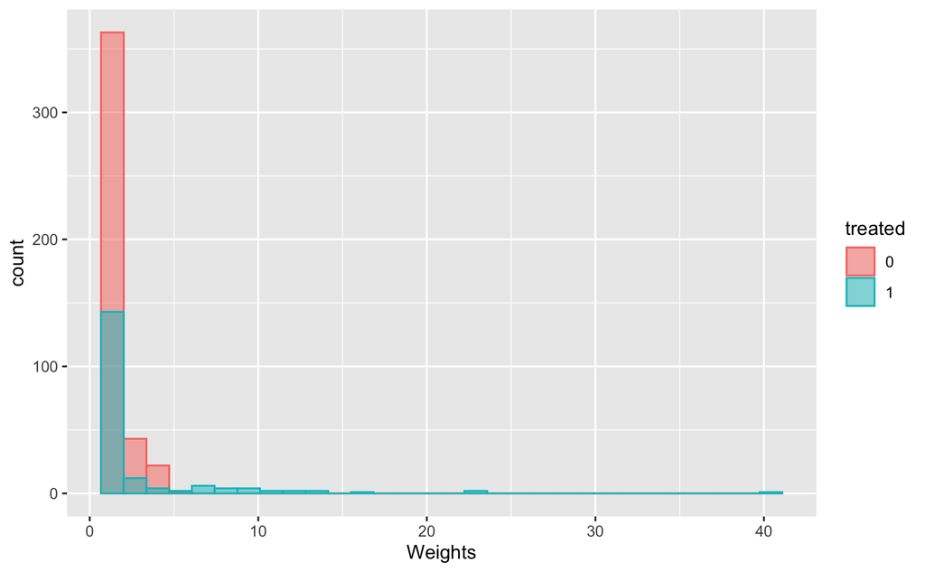

```r
## Calculate the raw weights (before normalization)
## Weights to estimate ATE
n.treated <- sum(lalonde$treat == 1)
n.control <- sum(lalonde$treat == 0)
weights <- ifelse(lalonde$treat == 1, 1/eps, 1/(1 - eps))

## Check the weights histogram
library(ggplot2)
temp.data <- data.frame(weights = weights, treated = as.factor(lalonde$treat))
ggplot(temp.data, aes(x = weights, fill = treated, color = treated)) +
  geom_histogram(alpha = 0.5, position = "identity") +
  xlab("Weights")
```

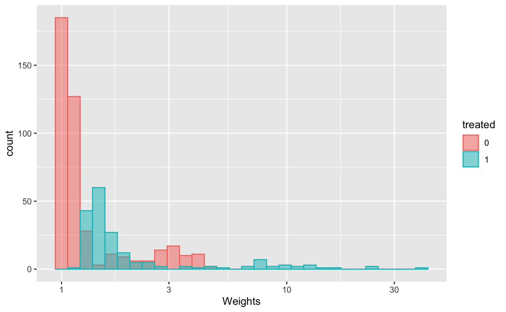

```r
## We can perform log transformation to make the histogram more informative
ggplot(temp.data, aes(x = weights, fill = treated, color = treated)) +
  geom_histogram(alpha = 0.5, position = "identity") +  scale_x_log10() +
  xlab("Weights")
```

- Visualize the estimated propensity scores

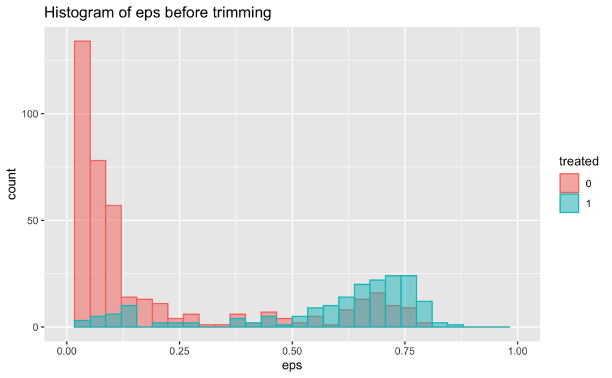

```r
temp.data.eps <- data.frame(eps = eps, treated = as.factor(lalonde$treat))
ggplot(temp.data.eps, aes(x = eps, fill = treated, color = treated)) +
  geom_histogram(alpha = 0.5, position = "identity") + xlim(c(0, 1)) +
  ggtitle("Histogram of eps before trimming")
```

We likely will do some trimming to make sure overlapping assumption is satisfied and probably will also improve covariates balancing.

- Check covariate balancing.

We can check covariate balancing from the love plot after inverse probability weighting. Here, we need to write our own function to draw the love plot.

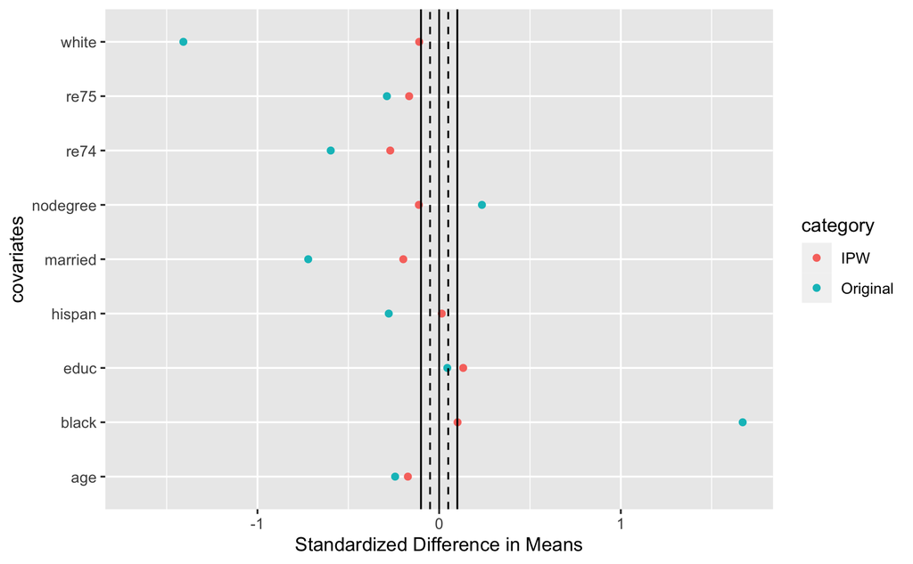

```r
## Need to change race (categorical) into indicators (numerical)
lalonde$black <- lalonde$race == "black"
lalonde$hispan <- lalonde$race == "hispan"
lalonde$white <- lalonde$race == "white"

## Draw love plot
love.plot = function(cov, treat,  ## cov is the matrix of covariates and treat is a vector of treatment assignment
                     weights = rep(1, length(treat)),
                     plot = F)
{

    ## mean with normalized weights \sum w_i x_i / (\sum w_i)
  treat.means <- colSums(cov[treat == 1,] * weights[treat == 1])/sum(weights[treat == 1])
  treat.var <- colSums(t(t(cov[treat == 1,]) - treat.means)^2 *
                          weights[treat == 1])/sum(weights[treat == 1])

  control.means <- colSums(cov[treat == 0,] * weights[treat == 0])/sum(weights[treat == 0])
  control.var <- colSums(t(t(cov[treat == 0,]) - control.means)^2 *
                          weights[treat == 0])/sum(weights[treat == 0])

  ## the standardized mean differences for every covariate
  smd <- (treat.means - control.means)/sqrt((treat.var + control.var)/2)
  names(smd) <- colnames(cov)

  if (plot == T) {
    plot.data <- data.frame(smd = smd, covariates = names(smd))
    range <- max(abs(smd))
    ggplot(plot.data) + geom_point(aes(x = as.numeric(smd), y = covariates)) +
      geom_vline(xintercept = 0) + xlim(-range, range) +
      labs(x = 'Standardized Difference in Means')
  }
  return(smd)
}

raw.smd <- love.plot(lalonde[, c(2:3, 5:8, 10:12)], lalonde$treat)
weighted.smd <- love.plot(lalonde[, c(2:3, 5:8, 10:12)], lalonde$treat, weights = weights)


plot.data <- data.frame(smd = c(raw.smd, weighted.smd),
                        covariates = c(names(raw.smd), names(weighted.smd)),
                        category = c(rep("Original", length(raw.smd)), rep("IPW", length(weighted.smd))))
range <- max(abs(plot.data$smd))

ggplot(plot.data) + geom_point(aes(x = as.numeric(smd), y = covariates, color = category)) +
      geom_vline(xintercept = c(-0.1, -0.05, 0, 0.05, 0.1),
                 linetype = c("solid", "dashed", "solid", "dashed", "solid")) +
      xlim(-range, range) +
      labs(x = 'Standardized Difference in Means')
```

Covariate balancing is greatly improved after IPW. There is still room for further improvement.

# 2. Trimming

## 2.1 Check weights and covariates balancing after trimming

- Perform trimming and check the histogram of weights

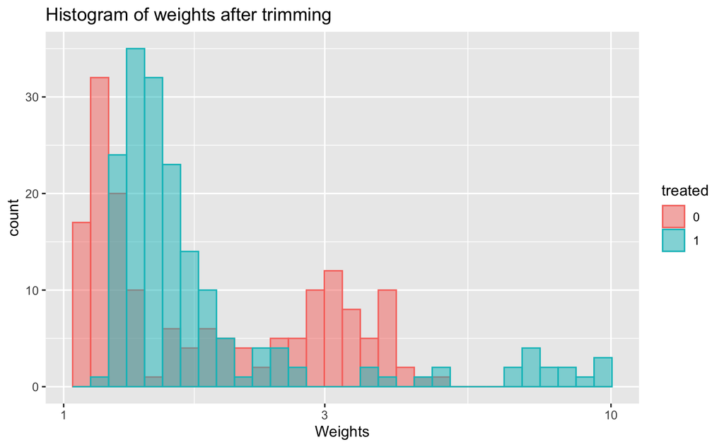

```r
rm.idx <- which(eps < 0.1 | eps > 0.9)

temp.data.trimmed <- temp.data[-rm.idx, ]
lalonde.trimmed <- lalonde[-rm.idx, ]

## Check the histogram of weights again

ggplot(temp.data.trimmed, aes(x = weights, fill = treated, color = treated)) +
  geom_histogram(alpha = 0.5, position = "identity") +  scale_x_log10() +
  xlab("Weights") + ggtitle("Histogram of weights after trimming")
```

- Check covariate balancing after trimming.

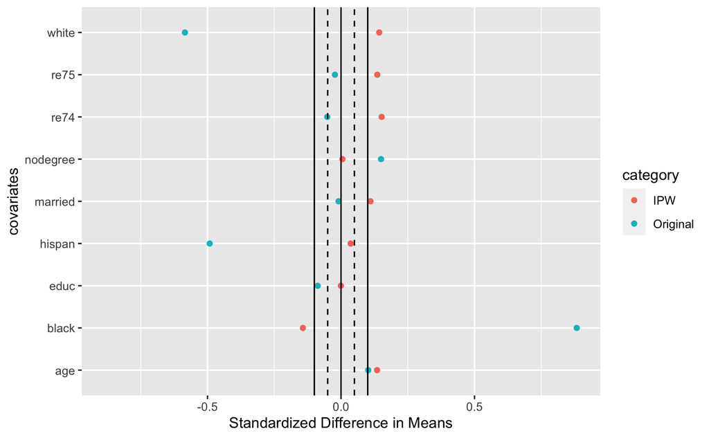

```r
raw.smd <- love.plot(lalonde.trimmed[, c(2:3, 5:8, 10:12)], lalonde.trimmed$treat)
weighted.smd <- love.plot(lalonde.trimmed[, c(2:3, 5:8, 10:12)], lalonde.trimmed$treat,
                          weights = weights[-rm.idx])
plot.data <- data.frame(smd = c(raw.smd, weighted.smd),
                        covariates = c(names(raw.smd), names(weighted.smd)),
                        category = c(rep("Original", length(raw.smd)), rep("IPW", length(weighted.smd))))
range <- max(abs(plot.data$smd))
ggplot(plot.data) + geom_point(aes(x = as.numeric(smd), y = covariates, color = category)) +
      geom_vline(xintercept = c(-0.1, -0.05, 0, 0.05, 0.1),
                 linetype = c("solid", "dashed", "solid", "dashed", "solid")) +
      xlim(-range, range) +
      labs(x = 'Standardized Difference in Means')
```

Though covariate balanicng of the raw data gets better, covariates balancing with IPW does not improve.

## 2.2 Refit the propensity score model after trimming

We do this because the covariate balancing the previous step is not satisfying.

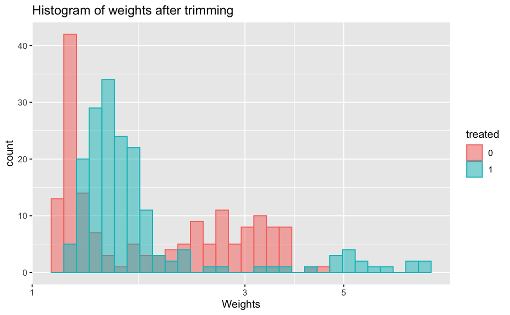

```r
## Refit the propensity score model
model.trimmed <- glm(treat ~ . , data = lalonde.trimmed[, -(9:12)], family = "binomial")
eps.trimmed <- predict(model.trimmed, type = "response")
weights.trimmed <- ifelse(lalonde.trimmed$treat == 1, 1/eps.trimmed, 1/(1 - eps.trimmed))
temp.data.trimmed$weights <- weights.trimmed

## Check the histogram of weights again

ggplot(temp.data.trimmed, aes(x = weights, fill = treated, color = treated)) +
  geom_histogram(alpha = 0.5, position = "identity") +  scale_x_log10() +
  xlab("Weights") + ggtitle("Histogram of weights after trimming")
```

- Check covariate balancing again.

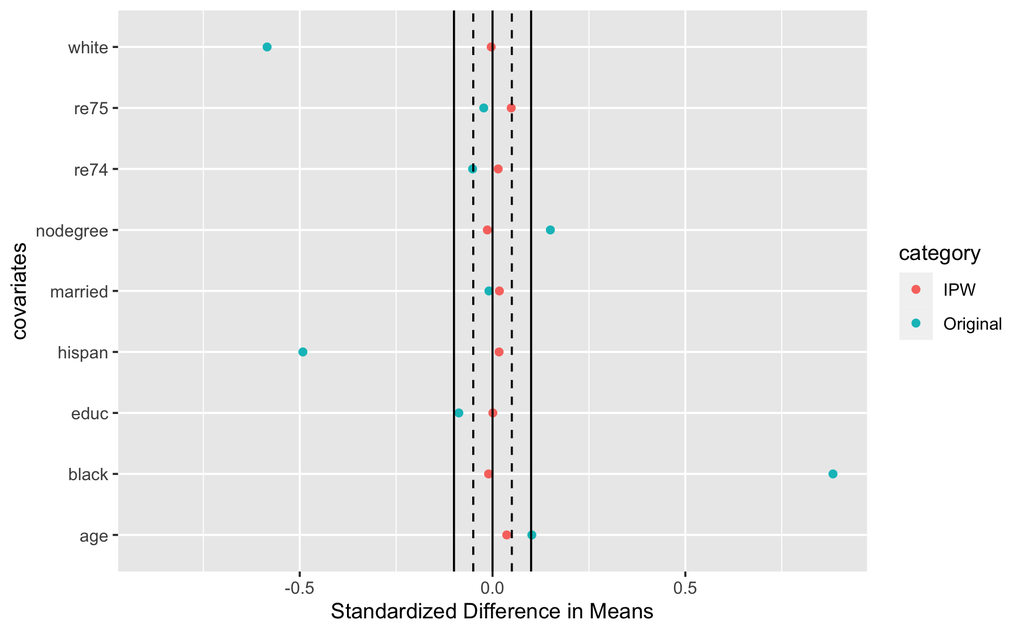

```r
raw.smd <- love.plot(lalonde.trimmed[, c(2:3, 5:8, 10:12)], lalonde.trimmed$treat)
weighted.smd <- love.plot(lalonde.trimmed[, c(2:3, 5:8, 10:12)], lalonde.trimmed$treat,
                          weights = weights.trimmed)
plot.data <- data.frame(smd = c(raw.smd, weighted.smd),
                        covariates = c(names(raw.smd), names(weighted.smd)),
                        category = c(rep("Original", length(raw.smd)), rep("IPW", length(weighted.smd))))
range <- max(abs(plot.data$smd))
ggplot(plot.data) + geom_point(aes(x = as.numeric(smd), y = covariates, color = category)) +
      geom_vline(xintercept = c(-0.1, -0.05, 0, 0.05, 0.1),
                 linetype = c("solid", "dashed", "solid", "dashed", "solid")) +
      xlim(-range, range) +
      labs(x = 'Standardized Difference in Means')
```

# 3. Estimate the ATE using IPW

- Estimate ATE by weighted least square regression

```r
lm.result <- lm(re78 ~ treat, weights = weights.trimmed, data = lalonde.trimmed)
summary(lm.result)
```

```
Call:
lm(formula = re78 ~ treat, data = lalonde.trimmed, weights = weights.trimmed)

Weighted Residuals:
   Min     1Q Median     3Q    Max
-16478  -7345  -2741   3852  61182

Coefficients:
            Estimate Std. Error t value Pr(>|t|)
(Intercept)   5402.7      537.4  10.053   <2e-16 ***
treat         1155.1      756.9   1.526    0.128
---
Signif. codes:  0 ‘***’ 0.001 ‘**’ 0.01 ‘*’ 0.05 ‘.’ 0.1 ‘ ’ 1

Residual standard error: 9888 on 339 degrees of freedom
Multiple R-squared:  0.006823,  Adjusted R-squared:  0.003894
F-statistic: 2.329 on 1 and 339 DF,  p-value: 0.1279
```

- Statistical inference treating the weights as fixed.

We use the Sandwich estimator allowing heteroscedastic noise levels between the treated and control grousp

```r
library(sandwich)
tau_hat <- lm.result$coefficients[2]
SE <- sqrt(diag(vcovHC(lm.result, type = "HC2")))[2]

## get the 95% CI
result <- c(tau_hat, SE, c(tau_hat- 1.96 * SE, tau_hat + 1.96 * SE))
names(result) <- c("est", "sd", "CI_lower", "CI_upper")
result
```

```
      est        sd  CI_lower  CI_upper
1155.0913  827.0484 -465.9235 2776.1062
```

- Statistical inference using bootstrap

```r
IPW_estimator <- function(W, Y, X) {
  ## Estimate propensity score
  model <- glm(W ~ X , family = "binomial")
  eps <- predict(model, type = "response")

  ## Calculate the weights
  weights <- ifelse(W == 1, 1/eps, 1/(1 - eps))

  ## Calculate weighted mean difference between treated and control group
  est <- lm(Y ~ W, weights = weights)$coef[2]
  return(est)
}

X <- model.matrix(model.trimmed)
Y <- lalonde.trimmed$re78
W <- lalonde.trimmed$treat

IPW_bootstrap <- function(W, Y, X, n.boot = 200){
  est <- IPW_estimator(W, Y, X)
  IPWboot <- sapply(1:n.boot, function(i) {
    id.boot <- sample(1:length(W), replace = T)
    IPW_estimator(W[id.boot], Y[id.boot], X[id.boot, ])
  })
  return(c(est, sd(IPWboot)))
}

SE_boostrap <- IPW_bootstrap(W, Y, X, 5000)[2]
result_bootstrap <- c(tau_hat, SE_boostrap,
                      c(tau_hat- 1.96 * SE_boostrap, tau_hat + 1.96 * SE_boostrap))
names(result_bootstrap) <- c("est", "sd (bootstrap)", "CI_lower (bootstrap)", "CI_upper (bootstrap)")
result_bootstrap
```

```
                 est       sd (bootstrap) CI_lower (bootstrap) CI_upper (bootstrap)
           1155.0913             869.8960            -549.9049            2860.0875
```